# Applied Computational Methods for Social Sciences

Lecture 15: Rasters and Raster Operations 1

Bogdan G. Popescu

bogdan.popescu@johncabot.edu

John Cabot University

## What You’ll Learn Today

1. What **rasters** are and the common raster file formats
2. Reading rasters with **`stars`** and exploring their attributes
3. Working with **satellite luminosity** (nighttime lights) data
4. **Subsetting** raster values and **vectorizing** cells
5. **Cropping** rasters to areas of interest

By the end, you’ll be able to load, inspect, and slice gridded data.

## Today

Today’s agenda includes:

- becoming familiar with others types of data in R:
- raster layers
- examining spatial and non-spatial properties of vectors

We will use `sf`, `stars`, and `units` packages.

## Reminder: Spatial Data Classes in R

- Spatial entries in GIS can be represented as a **vector** or as a **raster**
- In the previous lecture, we examine vectors and geometric operations with vectors.

## Raster

Rasters are matrices or an array representing a rectangular area on the surface of the earth.

They contain elements such as :

## Raster

## Raster with the Same Extent but Different Resolutions

## Raster file formats

- “Simple” rasters
  - **GeoTIFF** (`.tif`)
  - **Erdas Imagine Image** (`.img`)
- “Complex” rasters (>3D and / or metadata)
  - **HDF** (`.hdf`, `.he5`)
  - **NetCDF** (`.nc`)

## Using R packages for rasters

There is one important package that we will work with: `stars`

`terra` is also another important package developed by the same authors

Both contain classes, and extensive functions for working with rasters in R

We will mostly work with `stars`

## The `stars` package

Unlike `terra` and `raster`, `stars` is very well integrated with `sf`

`sf` is the package that we have used for vector analysis.

## Example of Raster: Luminosity

A typical example of raster is satellite luminosity

Within economics, researchers use satellite luminosity as a proxy for economic activity

## Luminosity in 2013

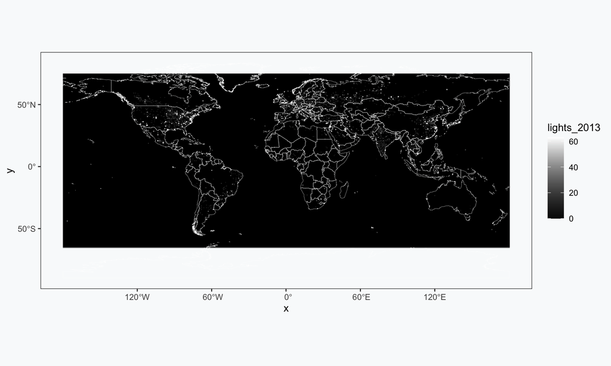

## Working with Luminosity

You can download satellite luminosity by going to https://www.ncei.noaa.gov/products/dmsp-operational-linescan-system

## Working with Luminosity

The next step is to scroll down to products

## Working with Luminosity

The next step is to scroll down to products

## Working with Luminosity

You can download these files by clicking on the links

## Working with Luminosity

Note that these are large files: Every zip file will range from 355 MB to 411.1 MB

The files are cloud-free composites

In cases where two satellites were collecting data - two composites were produced.

## Working with Luminosity

## Working with Luminosity

Note that these are large files: Every zip file will range from 355 MB to 411.1 MB

The files are cloud-free composites

In cases where two satellites were collecting data - two composites were produced.

The products are 30 arc second grids, spanning -180 to 180 degrees longitude and -65 to 75 degrees latitude.

Each composite set is named with the satellite and the year (F121995 is from DMSP satellite number F12 for the year 1995)

## Working with Luminosity

Three types of images are available:

- **F1?YYYY_v4b_cf_cvg.tif:** Cloud-free coverages tally the total number of observations that went into each 30 arc second grid cell
- **F1?YYYY_v4b_avg_vis.tif** Raw avg_vis contains the average of the visible band digital number values with no further filtering.
- **F1?YYYY_v4b_stable_lights.avg_vis.tif** The cleaned up avg_vis contains the lights from cities, towns, and other sites with persistent lighting, including gas flares.

## Working with Luminosity

The DMSP/OLS resolution is approximately 1000m

It comprises six different DMSP satellites:

- F10 (1992–1994)
- F12 (1994–1999)
- F14 (1997–2003)
- F15 (2000–2007)
- F16 (2004–2009)
- F18 (2010–2013)

## Working with Luminosity

After downloading, your folder should look like below:

## Working with Luminosity

You download all the relevant files for this exercise below:

- [Modern Borders](https://www.dropbox.com/scl/fo/stmy2wpq597pws5iog4pq/h?rlkey=w9bgd0r7sbiz9rjevq7r7kux2&dl=0)
- [Luminosity for the whole world 1992](https://www.dropbox.com/scl/fi/1vzxvcacjoi2ttu6ymqu6/F101992.v4.tar?rlkey=rm81314kga2q6oxgn5zhb48en&dl=0) (300MB)
- [All luminosity files for the whole world 1992-2012](https://www.dropbox.com/scl/fo/tgc448sx9a21g6mdab482/h?rlkey=tuf1xk2hnoli7wwfmcspz24u3&dl=0) (10.64GB)

## Working with Luminosity

These are the steps to have the data ready for plotting in `ggplot`

```r
#Step1: Read country borders
sf_use_s2(FALSE)
borders <- st_read(dsn="./data/boundaries/all-country-boundaries.shp", quiet = TRUE)
borders<-st_simplify(borders, dTolerance=0.1)
```

This what the shape file looks like:

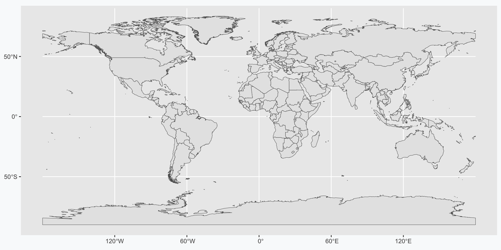

```r
ggplot()+
  geom_sf(data=borders)
```

## Working with Luminosity

These are the steps to have the data ready for plotting in `ggplot`

```r
#Step2: Creating a folder called "F101992"
target_dir <- "./data/luminosity/F101992"
#Step3: Create the target directory if it doesn't exist
if (!dir.exists(target_dir)) {
  dir.create(target_dir)
}
```

## Working with Luminosity

This is what our folder looked like before running the code.

## Working with Luminosity

These are the steps to have the data ready for plotting in `ggplot`

```r
#Step2: Creating a folder called "F101992"
target_dir <- "./data/luminosity/F101992"
#Step3: Create the target directory if it doesn't exist
if (!dir.exists(target_dir)) {
  dir.create(target_dir)
}
```

## Working with Luminosity

This is what our folder looks like after running the code.

## Working with Luminosity

```r
#Step4: Unzip the file
untar("./data/luminosity/F101992.v4.tar", exdir = target_dir)
```

## Working with Luminosity

This is what our folder looks like before running the code.

## Working with Luminosity

This is what our folder looks like after running the code.

## Working with Luminosity

```r
#Step5: Unzip the file further
R.utils::gunzip("./data/luminosity/F101992/F101992.v4b_web.avg_vis.tif.gz", remove = FALSE, overwrite=TRUE)
```

## Working with Luminosity

This is what our folder looks like before running the code.

## Working with Luminosity

This is what our folder looks like after running the code.

## Working with Luminosity

```r
#Step6: Read the raster
f1992<-read_stars("./data/luminosity/F101992/F101992.v4b_web.avg_vis.tif")
#Step7: Make sure the two files have the same CRS
st_crs(f1992)<-st_crs(borders)
```

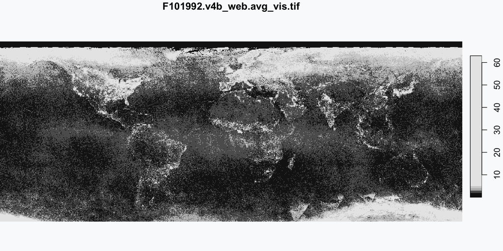

```r
plot(f1992)
```

## Working with Luminosity

Note: do not try to plot it yet with `ggplot`.

The raster is too detailed.

It will freeze your computer.

## Working with Luminosity

This is how we can reduce the resolution of a raster

```r
#Step8: Reduce the resolution of the raster: Higher dx/day values mean lower resolution
f1992b<-st_warp(f1992, st_as_stars(st_bbox(f1992), dx = 0.7, dy = 0.7))
```

```r
#Step8: Reduce the resolution of the raster: Higher dx/day values mean lower resolution
f1992b_reduced<-st_warp(f1992, st_as_stars(st_bbox(f1992), dx = 2.5, dy = 2.5))
```

## Working with Luminosity

Let us now compare the two

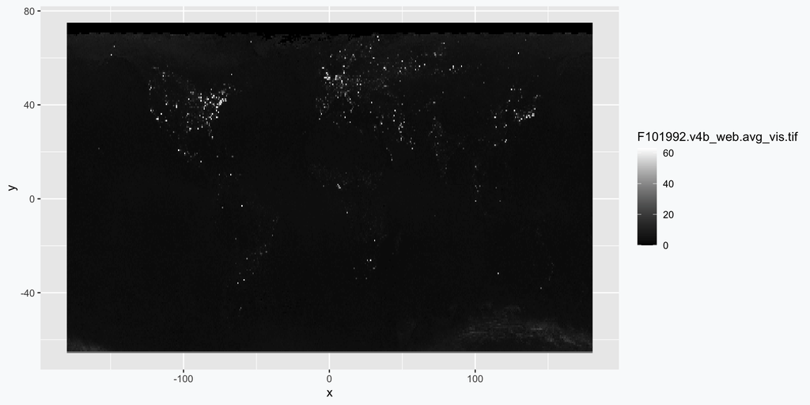

```r
ggplot()+
  geom_stars(data=f1992b)+
  scale_fill_gradientn(colours=c("black","white"))
```

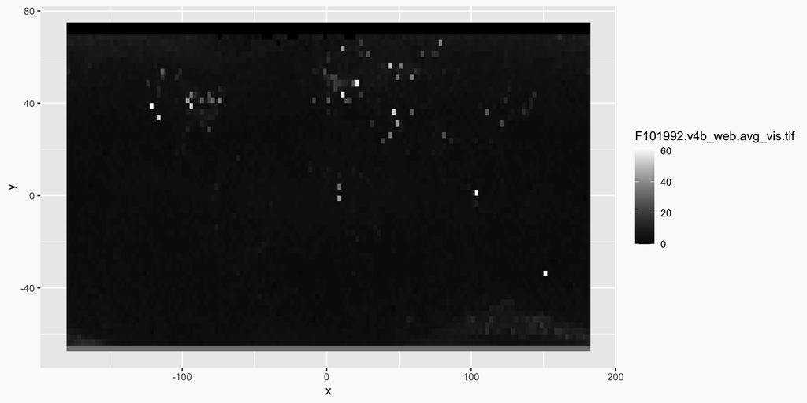

```r
ggplot()+
  geom_stars(data=f1992b_reduced)+
  scale_fill_gradientn(colours=c("black","white"))
```

## Working with Luminosity

We can finally add a more friendly name to the raster

```r
#Step9: Rename the raster
names(f1992b)<-"lights_1992"
```

## Working with Luminosity

Just reviewing the steps:

```r
#Step1: Read country borders
borders <- st_read(dsn="./data/boundaries/all-country-boundaries.shp", quiet = TRUE)
#Step2: Creating a folder called "F101992"
target_dir <- "./data/luminosity/F101992"
#Step3: Create the target directory if it doesn't exist
if (!dir.exists(target_dir)) {
  dir.create(target_dir)
}
#Step4: Unzip the file
untar("./data/luminosity/F101992.v4.tar", exdir = target_dir)
#Step5: Unzip the file further
R.utils::gunzip("./data/luminosity/F101992/F101992.v4b_web.avg_vis.tif.gz", remove = FALSE, overwrite=TRUE)
#Step6: Read the raster
f1992<-read_stars("./data/luminosity/F101992/F101992.v4b_web.avg_vis.tif")
#Step7: Make sure the two files have the same CRS
st_crs(f1992)<-st_crs(borders)
#Step8: Reduce the resolution of the raster: Higher dx/day values mean lower resolution
f1992b<-st_warp(f1992, st_as_stars(st_bbox(f1992), dx = 0.7, dy = 0.7))
#Step9: Rename the raster
names(f1992b)<-"lights_1992"

fig<-ggplot()+
  geom_stars(data=f1992b)+
  scale_fill_gradientn(colours=c("black","white"))+
  geom_sf(data=borders, linewidth = 0.1, fill = NA, color = "white", alpha=0.5)+
  theme_bw()+
  theme(panel.grid.major = element_blank(), panel.grid.minor = element_blank())
```

## Luminosity in 1992

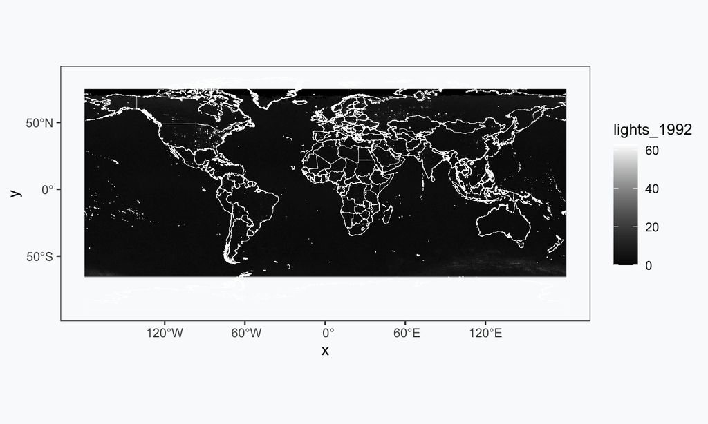

## Luminosity in 1992 in Europe

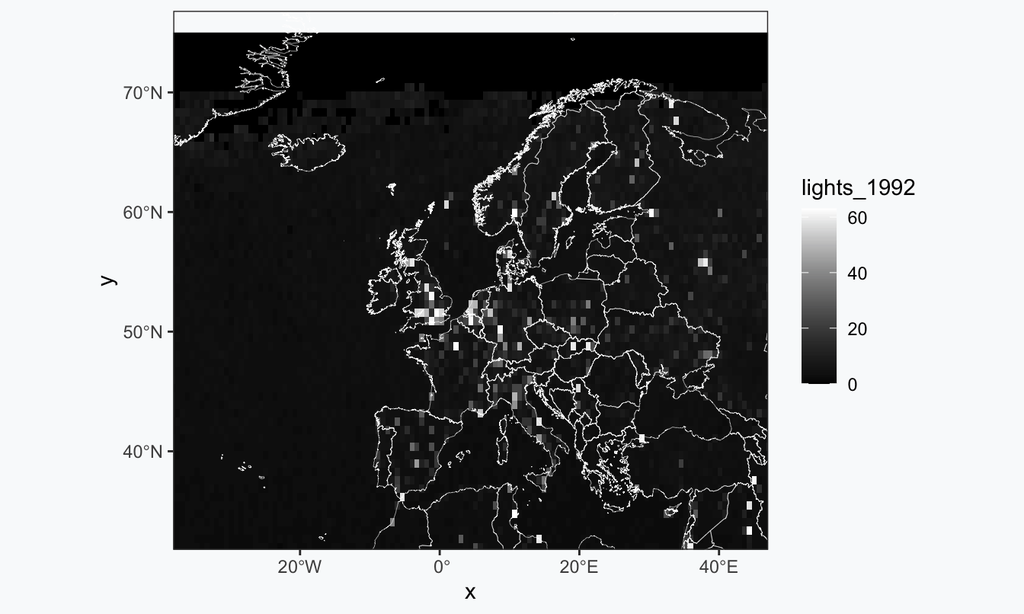

```r
norway<-subset(borders, SOVEREIGNT == "Norway")
max_lat_y_eu<-st_bbox(norway)["ymax"]

greece<-subset(borders, SOVEREIGNT == "Greece")
min_lat_y_eu<-st_bbox(greece)["ymin"]

ukraine<-subset(borders, SOVEREIGNT == "Ukraine")
max_lon_x_eu<-st_bbox(ukraine)["xmax"]

portugal<-subset(borders, SOVEREIGNT == "Portugal")
min_lon_x_eu<-st_bbox(portugal)["xmin"]

ggplot()+
  geom_stars(data=f1992b)+
  scale_fill_gradientn(colours=c("black","white"))+
  geom_sf(data=borders, linewidth = 0.1, fill = NA, color = "white", alpha=0.5)+
  coord_sf(xlim = c(min_lon_x_eu-3, max_lon_x_eu+3), ylim = c(min_lat_y_eu-1, max_lat_y_eu-6))+
  theme_bw()+
  theme(panel.grid.major = element_blank(), panel.grid.minor = element_blank())
```

## Raster Values and Properties

The print method gives a summary of the raster’s properties.

```r
print(f1992b)
```

```
stars object with 2 dimensions and 1 attribute
attribute(s):
             Min. 1st Qu. Median     Mean 3rd Qu. Max. NAs
lights_1992     0       2      3 3.384738       4   63 515
dimension(s):
  from  to offset delta refsys x/y
x    1 515   -180   0.7 WGS 84 [x]
y    1 201     75  -0.7 WGS 84 [y]
```

The class function allows us to see the type of object that we’re dealing with

```r
class(f1992b)
```

```
[1] "stars"
```

## Raster Values and Properties

Fundamentally, a `stars` object is a collection of `matrix` or `array` objects.

This is along with additional properties of the dimensions, such as dimension names, Coordinate Reference Systems (CRS).

## Raster Values and Properties

We can display the structure of a `stars` object using `str`.

```r
str(f1992b)
```

```
List of 1
 $ lights_1992: num [1:515, 1:201] 0 0 0 0 0 0 0 0 0 0 ...
 - attr(*, "dimensions")=List of 2
  ..$ x:List of 7
  .. ..$ from  : num 1
  .. ..$ to    : num 515
  .. ..$ offset: num -180
  .. ..$ delta : num 0.7
  .. ..$ refsys:List of 2
  .. .. ..$ input: chr "WGS 84"
  .. .. ..$ wkt  : chr "GEOGCRS[\"WGS 84\",\n    DATUM[\"World Geodetic System 1984\",\n        ELLIPSOID[\"WGS 84\",6378137,298.257223"| __truncated__
  .. .. ..- attr(*, "class")= chr "crs"
  .. ..$ point : logi NA
  .. ..$ values: NULL
  .. ..- attr(*, "class")= chr "dimension"
  ..$ y:List of 7
  .. ..$ from  : num 1
  .. ..$ to    : num 201
  .. ..$ offset: num 75
  .. ..$ delta : num -0.7
  .. ..$ refsys:List of 2
  .. .. ..$ input: chr "WGS 84"
  .. .. ..$ wkt  : chr "GEOGCRS[\"WGS 84\",\n    DATUM[\"World Geodetic System 1984\",\n        ELLIPSOID[\"WGS 84\",6378137,298.257223"| __truncated__
  .. .. ..- attr(*, "class")= chr "crs"
  .. ..$ point : logi NA
  .. ..$ values: NULL
  .. ..- attr(*, "class")= chr "dimension"
  ..- attr(*, "raster")=List of 4
  .. ..$ affine     : num [1:2] 0 0
  .. ..$ dimensions : chr [1:2] "x" "y"
  .. ..$ curvilinear: logi FALSE
  .. ..$ blocksizes : NULL
  .. ..- attr(*, "class")= chr "stars_raster"
  ..- attr(*, "class")= chr "dimensions"
 - attr(*, "class")= chr "stars"
```

## Raster Values and Properties

From this, we see that we have the `f1992b` object of length 1.

The 2nd line in the `str` printout specifies the name and contents of the first (and only) item in the list, namely its type, dimensions, and a sample of the first few values.

In our case, the first item is `lights_1992`, and it is a matrix with 515 rows and 201 columns

## Raster Attributes and Values

To access some of the attributes of our objects, we can type:

```r
names(f1992b)
```

```
[1] "lights_1992"
```

We can change names easily in the following wat:

```r
names(f1992b)<-"lum_1992"
names(f1992b)
```

```
[1] "lum_1992"
```

## Accessing Attributes by Name

We can access our raster’s attributes by using the `list` access methods

```r
#f1992b$lights_1992
f1992b[["lum_1992"]][1:10, 1:10]
```

```
      [,1] [,2] [,3] [,4] [,5] [,6] [,7] [,8] [,9] [,10]
 [1,]    0    0    0    0    0    0    0   10    7     9
 [2,]    0    0    0    0    0    0    0    6    7     6
 [3,]    0    0    0    0    0    0    0    5    6     9
 [4,]    0    0    0    0    0    0    0    9    6     9
 [5,]    0    0    0    0    0    0    0    8    8     8
 [6,]    0    0    0    0    0    0    0    9    9     7
 [7,]    0    0    0    0    0    0    0    8    7     8
 [8,]    0    0    0    0    0    0    0    4   10     9
 [9,]    0    0    0    0    0    0    0    6    7     9
[10,]    0    0    0    0    0    0    0    0    8     9
```

This is how we demonstrate that our file is a matrix

```r
#Using names
class(f1992b$lum_1992)
```

```
[1] "matrix" "array"
```

```r
#Using index
class(f1992b[[1]])
```

```
[1] "matrix" "array"
```

## Accessing Attributes by Name

```r
#Using names
dim(f1992b$lum_1992)
```

```
  x   y
515 201
```

```r
#Using index
dim(f1992b[[1]])
```

```
  x   y
515 201
```

## Subset operators in R

| Syntax | Objects | Returns |
| --- | --- | --- |
| `x[i]` | **vector**, `list` | Subset `i` |
| `x[i, j]` | `data.frame`, `matrix` | Subset `i`, `j` |
| `x[i, j, k]` | `array` | Subset `i`, `j`, `k` |
| `x[[i]]` | vectors, `lists` | Single element `i` |
| `x$i` | `data.frame`, `list` | Single column or element `i` |
| `x@n` | S4 objects | Slot `n` |

## Dimensions and spatial properties

We can use the following function to get at important raster properties

```r
# Number of rows
nrow(f1992b)
```

```
  x
515
```

```r
# Number of columns
ncol(f1992b)
```

```
  y
201
```

```r
# All dimensions
dim(f1992b)
```

```
  x   y
515 201
```

```r
# Extent of a raster
st_bbox(f1992b)
```

```
      xmin       ymin       xmax       ymax
-180.00417  -65.69583  180.49583   75.00417
```

## Dimensions and spatial properties

The other properties of rasters can be extracted in the following way:

```r
st_dimensions(f1992b)$x$offset  ## x-axis origin
```

```
[1] -180.0042
```

```r
st_dimensions(f1992b)$y$offset  ## x-axis origin
```

```
[1] 75.00417
```

```r
st_dimensions(f1992b)$x$delta  ## x-axis resolution
```

```
[1] 0.7
```

```r
st_dimensions(f1992b)$y$delta  ## y-axis resolution
```

```
[1] -0.7
```

Note that the resolution is separate for `x` and `y`.

If the (absolute) resolution is equal for both, raster pixels are square.

When the `x` and `y` resolutions are unequal, raster pixels are non-square rectangles.

## Dimensions and spatial properties

We can find out the crs of our raster using the `st_crs` function

```r
st_crs(f1992b)
```

```
Coordinate Reference System:
  User input: WGS 84
  wkt:
GEOGCRS["WGS 84",
    DATUM["World Geodetic System 1984",
        ELLIPSOID["WGS 84",6378137,298.257223563,
            LENGTHUNIT["metre",1]]],
    PRIMEM["Greenwich",0,
        ANGLEUNIT["degree",0.0174532925199433]],
    CS[ellipsoidal,2],
        AXIS["latitude",north,
            ORDER[1],
            ANGLEUNIT["degree",0.0174532925199433]],
        AXIS["longitude",east,
            ORDER[2],
            ANGLEUNIT["degree",0.0174532925199433]],
    ID["EPSG",4326]]
```

## Accessing Raster Values

As indicated, raster values can be extracted directly, as a `matrix` or as an `array`.

For example:

```r
#Printing only the first 10 rows and the first 10 columns
f1992b$lum_1992[1:10, 1:10]
```

```
      [,1] [,2] [,3] [,4] [,5] [,6] [,7] [,8] [,9] [,10]
 [1,]    0    0    0    0    0    0    0   10    7     9
 [2,]    0    0    0    0    0    0    0    6    7     6
 [3,]    0    0    0    0    0    0    0    5    6     9
 [4,]    0    0    0    0    0    0    0    9    6     9
 [5,]    0    0    0    0    0    0    0    8    8     8
 [6,]    0    0    0    0    0    0    0    9    9     7
 [7,]    0    0    0    0    0    0    0    8    7     8
 [8,]    0    0    0    0    0    0    0    4   10     9
 [9,]    0    0    0    0    0    0    0    6    7     9
[10,]    0    0    0    0    0    0    0    0    8     9
```

## Accessing Raster Values

A histogram will help us identify the raster values distribution

```r
#Turning the object into a dataframe
df<-st_as_sf(f1992b)
```

Here is the difference between the original raster and the dataframe

```r
#The raster
class(f1992b)
```

```
[1] "stars"
```

```r
#The dataframe
class(df)
```

```
[1] "sf"         "data.frame"
```

## Accessing Raster Values

A histogram will help us identify the raster values distribution

And here is how we can plot the raster vs. the dataframe

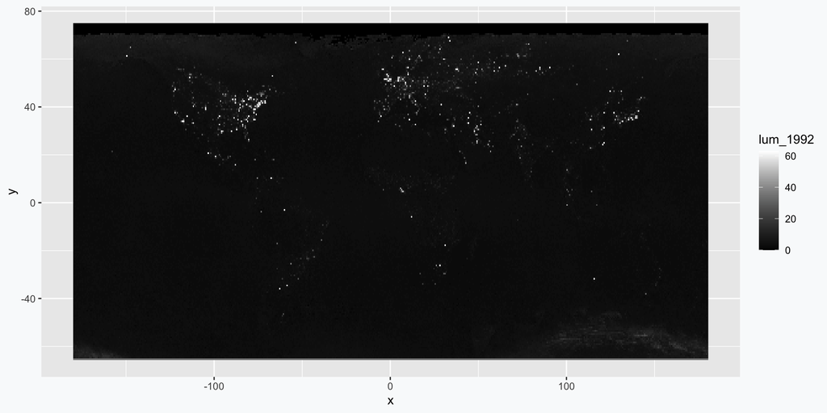

```r
ggplot()+
  geom_stars(data=f1992b)+
  scale_fill_gradientn(colours=c("black","white"))
```

[figure not shown]

```r
ggplot()+
  geom_sf(data=df, aes(fill=lum_1992),
          linewidth=0)+
  scale_fill_gradientn(colours=c("black","white"))+
  theme_bw()
```

## Accessing Raster Values

And this is what the data looks like:

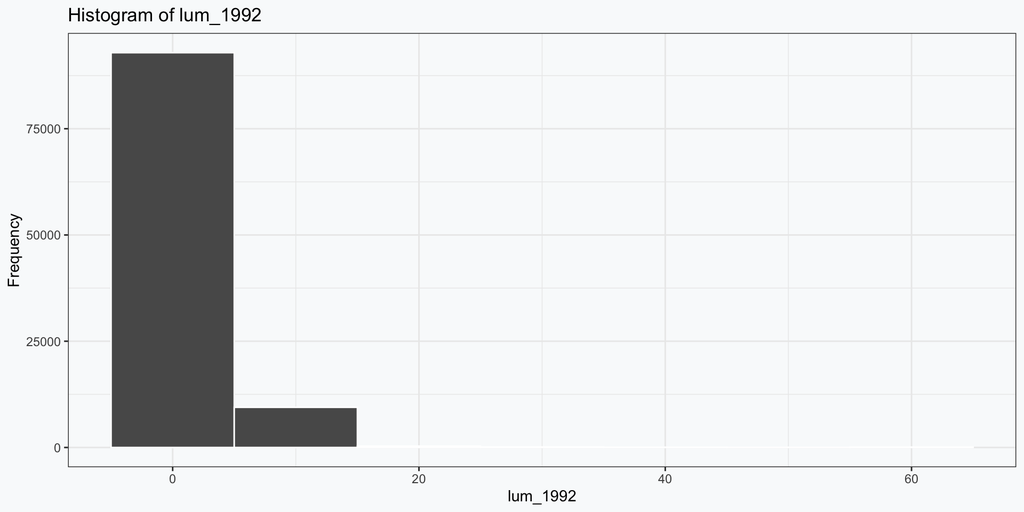

```r
#Creating a histogram
ggplot(df, aes(x = lum_1992)) +
  geom_histogram(binwidth = 10, color = "white") +
  ggtitle("Histogram of lum_1992") +
  xlab("lum_1992") +
  ylab("Frequency")+
  theme_bw()
```

## Accessing Raster Values

This is because 71 percent of the Earth’s surface is water-covered.

The important part is that by transforming the stars object into a dataframe (grid), we can perform the usual operations dedicated to dataframes.

For example: `glimpse`:

```r
library(dplyr)
glimpse(df)
```

```
Rows: 103,000
Columns: 2
$ lum_1992 <dbl> 0, 0, 0, 0, 0, 0, 0, 0, 0, 0, 0, 0, 0, 0, 0, 0, 0, 0, 0, 0, 0…
$ geometry <POLYGON [°]> POLYGON ((-180.0042 75.0041..., POLYGON ((-179.3042 7…
```

## Accessing Raster Values

We can also calculate the mean, sd, min, and max

```r
mean(df$lum_1992, na.rm=T)
```

```
[1] 3.384738
```

```r
sd(df$lum_1992, na.rm=T)
```

```
[1] 3.161684
```

```r
min(df$lum_1992, na.rm=T)
```

```
[1] 0
```

```r
max(df$lum_1992, na.rm=T)
```

```
[1] 63
```

## Mapping the World

This is what luminosity around the world looks like

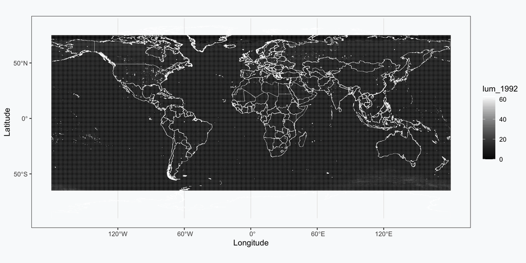

```r
p1<- ggplot()+
  geom_sf(data=df, aes(fill=lum_1992),
          linewidth=0)+
  scale_fill_gradientn(colours=c("black","white"))+
  geom_sf(data=borders, linewidth = 0.1, fill = NA, color = "white", alpha=0.5)+
  xlab("Longitude") + ylab("Latitude")+
  theme_bw()+
  coord_sf()
p1
```

## The Histogram

This is what the data looks like:

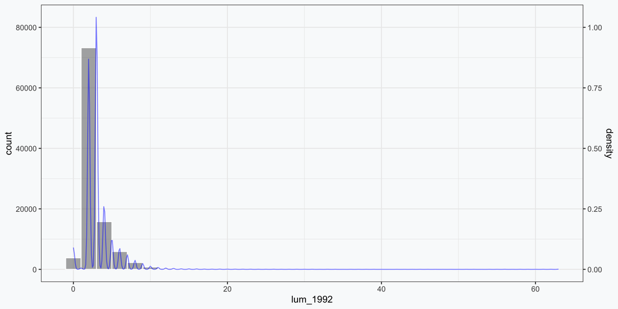

```r
p2<- ggplot(df, aes(lum_1992)) +
  guides(color = "none") +
  geom_histogram(binwidth = 2,
                 color = "white",
                 alpha = 0.5)+
  #Adding density and multiplying by a manually defined value
  #for visibility
  geom_density(aes(y = after_stat(density)* 80000),
               fill=NA, color=alpha("blue", 0.5))+
  #Adding a secondary axis
  scale_y_continuous(name = "count",
                     sec.axis =
                       sec_axis(~.x/80000,
                                name = "density"))+
  theme_bw()
p2
```

## Mapping Lights in Central Rome

Let’s focus on Italy.

You can download the [Rome central area polygon](https://www.dropbox.com/scl/fo/6jgeuiqkfwousp3iq9a25/h?rlkey=yyf2sgesl3jpwapocbwhr2mqz&dl=0)

You can also download the [main streets for the central area](https://www.dropbox.com/s/9ekpzqjy83fi8wx/selection.gdb.zip?dl=0)

Make sure you place them in the relevant folder.

## Mapping Lights in Central Rome: Cropping Rasters

Let’s focus on Italy

```r
#Step1: Reading the central polygon
relev_poly<-st_read(dsn="./data/rome_center/central_polygon.shp", quiet = T)
#Step2: Reading roads
gis_osm_roads <- st_read(dsn="./data/selection.gdb", layer="gis_osm_roads", quiet = T)
#Step3: Extracting the bix from the central polygon
ext2<-st_bbox(relev_poly)
#Step4: Ensuring the same crs for the polygon as for the raster
st_crs(relev_poly)<-st_crs(f1992)
#Step5: Cropping the raster
rc <- st_crop(f1992, relev_poly)
```

## Mapping Lights in Central Rome: Cropping Rasters

This is how the original vs. the cropped raster compare

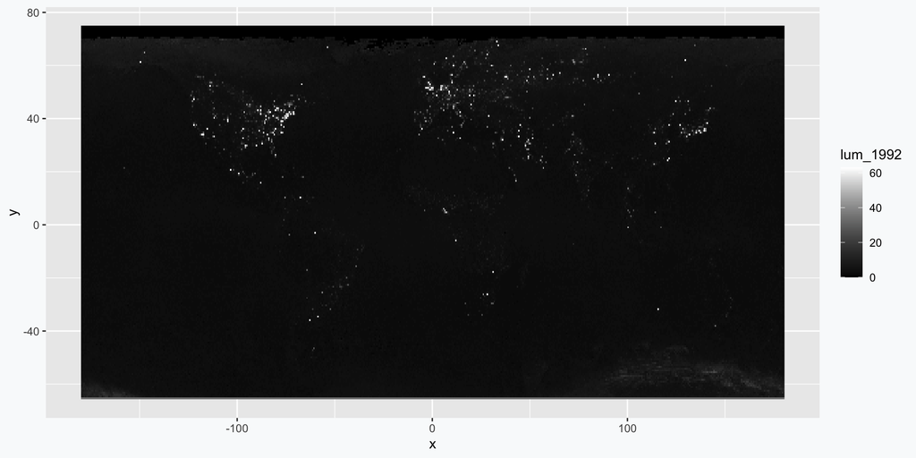

```r
ggplot()+
  geom_stars(data=f1992b)+
  scale_fill_gradientn(colours=c("black","white"))
```

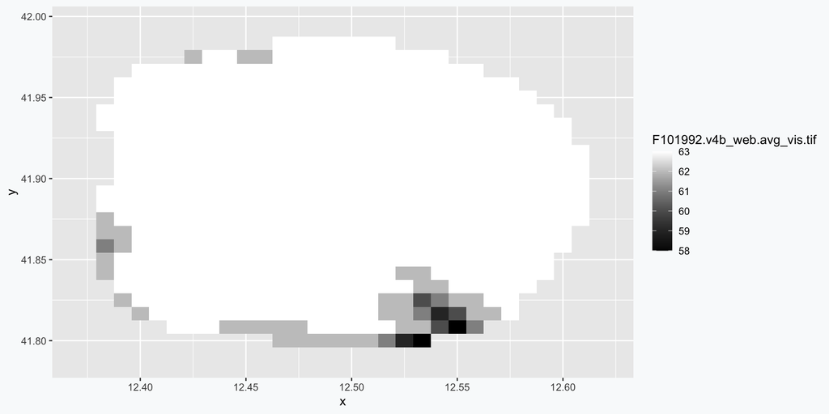

```r
ggplot()+
  geom_stars(data=rc)+
  scale_fill_gradientn(colours=c("black","white"), na.value=NA)
```

## Mapping Lights in Central Rome

We can finally add the roads in Rome to get more context.

```r
#Step6: Mapping everything
ggplot()+
  geom_stars(data = rc)+
  geom_sf(data = relev_poly, color="white", fill=NA)+
  geom_sf(data = gis_osm_roads, color="grey50", linewidth=0.05)+
  theme_bw()+
  scale_fill_gradientn(colours=c("black","white"), na.value=NA)
```

## Mapping Lights in Central Rome

Let’s focus on Italy

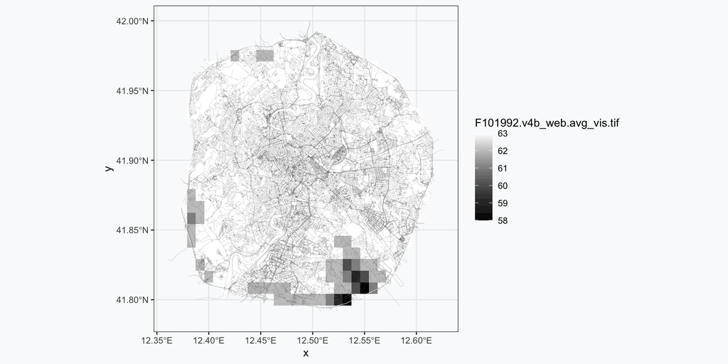

## Mapping Lights in Central Rome

Every grid has a value:

```r
#Turning the object into a dataframe
rc2<-st_as_sf(rc)
names(rc2)[1]<-"lum_1992"
#Step6: Mapping everything
ggplot()+
  geom_sf(data = rc2, aes(fill=lum_1992), linewidth=0)+
  geom_sf(data = relev_poly, color="white", fill=NA)+
  geom_sf(data = gis_osm_roads, color="grey50", linewidth=0.05)+
  theme_bw()+
  scale_fill_gradientn(colours=c("black","white"), na.value=NA)+
  geom_sf_text(data = rc2,
  aes(label = lum_1992, geometry = geometry),
  color = ifelse(rc2$lum_1992 < 61, "white", "black"), size = 1.5)
```

## Mapping Lights in Central Rome

Every grid has a value:

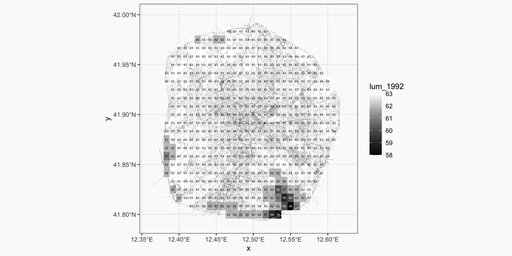

## Mapping Lights in Central Rome

Let’s zoom in:

```r
#Turning the object into a dataframe
rc2<-st_as_sf(rc)
names(rc2)[1]<-"lum_1992"
#Step6: Mapping everything
ggplot()+
  geom_sf(data = rc2, aes(fill=lum_1992), linewidth=0)+
  geom_sf(data = relev_poly, color="white", fill=NA)+
  geom_sf(data = gis_osm_roads, color="grey50", linewidth=0.05)+
  theme_bw()+
  scale_fill_gradientn(colours=c("black","white"), na.value=NA)+
  geom_sf_text(data = rc2,
  aes(label = lum_1992, geometry = geometry),
  color = ifelse(rc2$lum_1992 < 61, "white", "black"),
  #aes(label = lum_1992, geometry = geometry, color = ifelse(lum_1992 < 61, "white", "black")),
  size = 4)+
  coord_sf(xlim = c(12.45, 12.60),
           ylim = c(41.87, 41.79))
```

## Mapping Lights in Central Rome

Let’s zoom in:

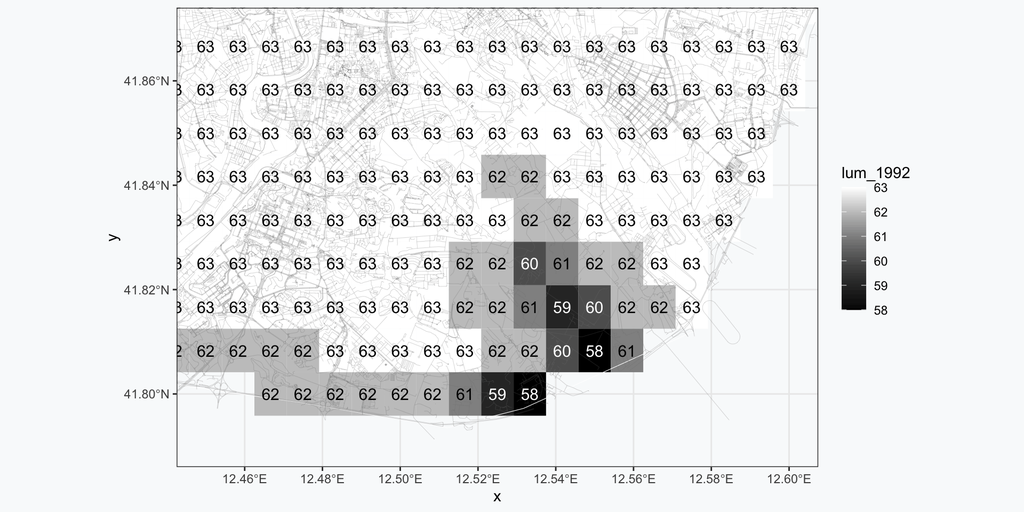

## Mapping Lights in Central Rome

As you might imagine, we can use different colors for these values:

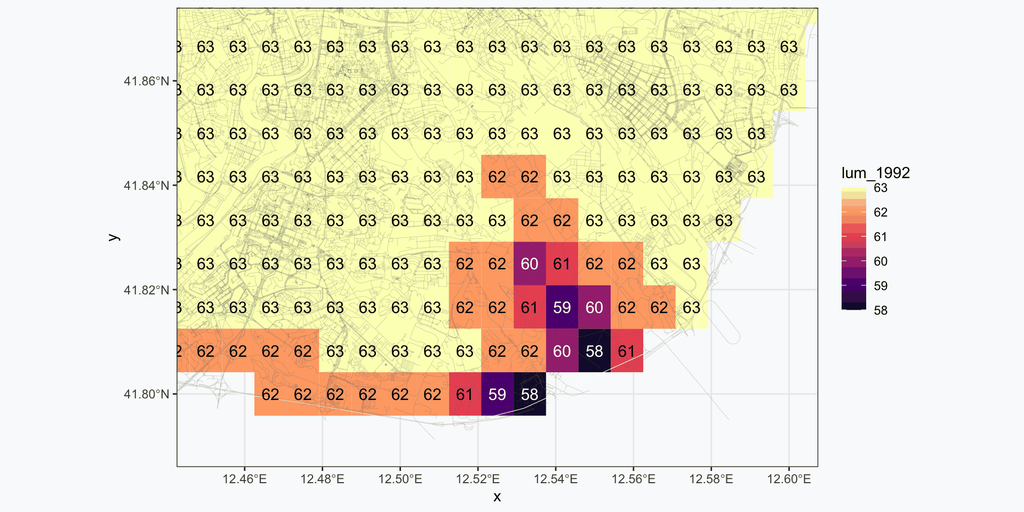

## Mapping Lights in Central Rome

As you might imagine, we can use different colors for these values:

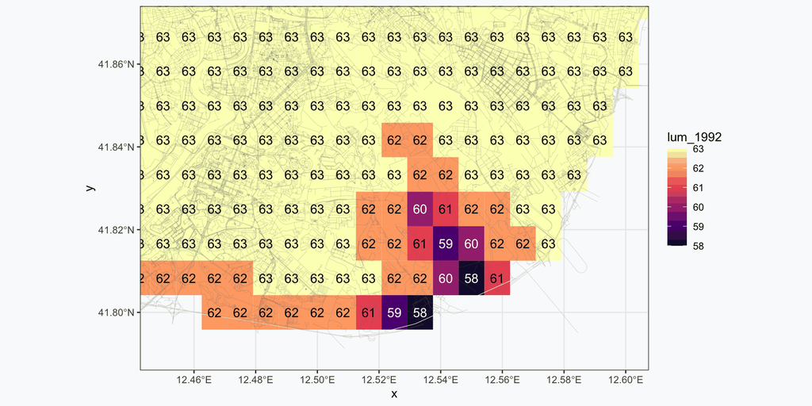

## Interractive Maps with `mapview`

```r
library(mapview)
mapview(rc2)
```

[interactive chart not shown]

## Replacing Values

We can easily replace the values inside the raster (grid) by using simple dataframe operations.

For example, let’s replace all the values that have 63 with NA:

```r
rc3<-rc2
rc3$lum_1992[rc3$lum_1992==63]<-NA
pic<-ggplot()+
  geom_sf(data = rc3, aes(fill=lum_1992), linewidth=0)+
  geom_sf(data = relev_poly, color="white", fill=NA)+
  geom_sf(data = gis_osm_roads, color="grey50", linewidth=0.05)+
  theme_bw()+
  scale_fill_viridis_c(option = "magma",begin = 0.1)+
  #scale_fill_gradientn(colours=c("black","white"))+
  geom_sf_text(data = rc2,
  aes(label = lum_1992, geometry = geometry),
  color = ifelse(rc3$lum_1992 < 61, "white", "black"),
  #aes(label = lum_1992, geometry = geometry, color = ifelse(lum_1992 < 61, "white", "black")),
  size = 4)+
  coord_sf(xlim = c(12.45, 12.60),
           ylim = c(41.87, 41.79))
pic
```

## Replacing Values

We can easily replace the values inside the raster (grid) by using simple dataframe operations.

For example, let’s replace all the values that have 63 with NA:

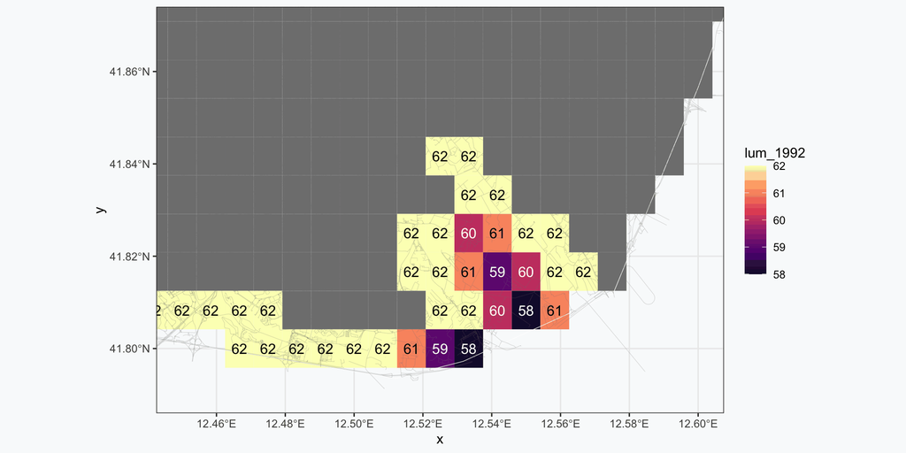

## Replacing Values

We can easily replace the values inside the raster (grid) by using simple dataframe operations.

For example, let’s replace all the values that have 63 with NA:

Let us now make the NA grids transparent

```r
rc3<-rc2
rc3$lum_1992[rc3$lum_1992==63]<-NA
pic<-ggplot()+
  geom_sf(data = rc3, aes(fill=lum_1992), linewidth=0)+
  geom_sf(data = relev_poly, color="white", fill=NA)+
  geom_sf(data = gis_osm_roads, color="grey50", linewidth=0.05)+
  theme_bw()+
  scale_fill_viridis_c(option = "magma",begin = 0.1,
                       na.value = "white")+
  #scale_fill_gradientn(colours=c("black","white"))+
  geom_sf_text(data = rc2,
  aes(label = lum_1992, geometry = geometry),
  color = ifelse(rc3$lum_1992 < 61, "white", "black"),
  #aes(label = lum_1992, geometry = geometry, color = ifelse(lum_1992 < 61, "white", "black")),
  size = 4)+
  coord_sf(xlim = c(12.45, 12.60),
           ylim = c(41.87, 41.79))
pic
```

## Replacing Values

We can easily replace the values inside the raster (grid) by using simple dataframe operations.

For example, let’s replace all the values that have 63 with NA:

Let us now make the NA grids transparent

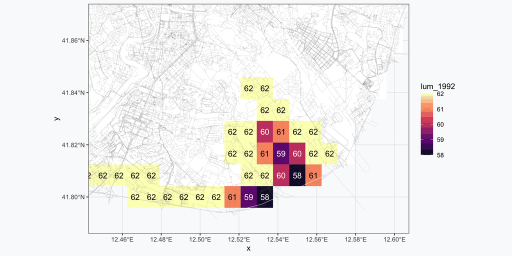

## Writing raster to file

We can of course write the grid as a shapefile for we can turn it back to a raster.

```r
rc3_raster = st_rasterize(rc3)
```

The raster

```r
class(rc3_raster)
```

```
[1] "stars"
```

The grid

```r
class(rc3)
```

```
[1] "sf"         "data.frame"
```

## Writing raster to file

We can write the raster in the following way:

```r
#Step1: Creating a folder called
target_dir <- "./data/output"
#Step2: Create the target directory if it doesn't exist
if (!dir.exists(target_dir)) {
  dir.create(target_dir)
}
#Step3: Writing the raster
write_stars(rc3_raster, './data/output/rc3_raster.tif')
```

## Writing the grid to file

We can write the grid in the following way:

```r
#Step1: Creating a folder called
target_dir <- "./data/output"
#Step2: Create the target directory if it doesn't exist
if (!dir.exists(target_dir)) {
  dir.create(target_dir)
}
#Step4: Writing the shape files
st_write(rc3, "./data/output/rc3_grid.shp", update = TRUE)
```

```
Updating layer `rc3_grid' to data source `./data/output/rc3_grid.shp' using driver `ESRI Shapefile'
Updating existing layer rc3_grid
Writing 535 features with 1 fields and geometry type Polygon.
```

## Conclusion

We have covered a lot of operations related to rasters

We learned about:

- different types of rasters
- plotting rasters
- dimensions of rasters
- accessing raster values
- working with luminosity
- subsetting rasters
- cropping rasters